# R Notebook

Mostafa

3/28/2021

```r
library (TSA)
library(tseries)
```

# 1.

```r
# 1.
set.seed(5)
AR1 <- arima.sim(list(order = c(1,0,0), ar = -0.6), n = 1000)  # phi = -0.6
MA1 <- arima.sim(list(order = c(0,0,1), ma = -0.8), n = 1000)  # theta = 0.8

par(mfrow=c(2,2))

acf (AR1, main="Sample ACF,  AR(1), phi = -0.6")
pacf(AR1, main="Sample PACF, AR(1), phi = -0.6")
```

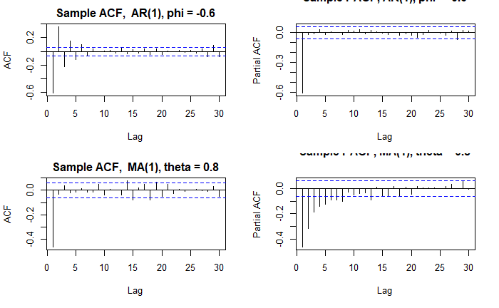

```r
acf (MA1, main="Sample ACF,  MA(1), theta = 0.8")
pacf(MA1, main="Sample PACF, MA(1), theta = 0.8")
```

```r
eacf(AR1) #, main="Sample PACF, AR(1), phi = -0.6"
```

```
AR/MA
  0 1 2 3 4 5 6 7 8 9 10 11 12 13
0 x x x x x x x o o o o  o  o  o
1 o o o o o o o o o o o  o  o  o
2 x o o o o o o o o o o  o  o  o
3 x x o o o o o o o o o  o  o  o
4 x x x o o o o o o o o  o  o  o
5 x x o x o o o o o o o  o  o  o
6 o x o o x o o o o o o  o  o  o
7 o x o o x x o o o o o  o  o  o
```

```r
eacf(MA1) #, main="Sample PACF, MA(1), theta = 0.8"
```

```
AR/MA
  0 1 2 3 4 5 6 7 8 9 10 11 12 13
0 x o o o o o o o o o o  o  o  x
1 x x o o o o o o o o o  o  o  o
2 x x x o o o o o o o o  o  o  o
3 x x x x o o o o o o o  o  o  o
4 x x o x o o o o o o o  o  o  o
5 x x o x o x o o o o o  o  o  o
6 x x x o o x x o o o o  o  o  o
7 x x x o x x x x o o o  o  o  o
```

**Answer**: Yes. The results based on ACF, PACF and EACF consistent with the true model for the time series. The reasons for each of them are as below step by step.  
- Sample ACF MA(1): A spike at lag 1 ==> A moving average of order 1 (q=1)  
- Sample PACF AR(1): A spike at lag 1 ==> An Autoregressive process of order 1 (P=1)  
- Sample EACF AR(1): A wedge of zeros with tip at (1,0) ==> ARMA(1,0)  
- Sample EACF MA(1): A wedge of zeros with tip at (0,1) ==> ARMA(0,1)

# 2.

## 2(a)

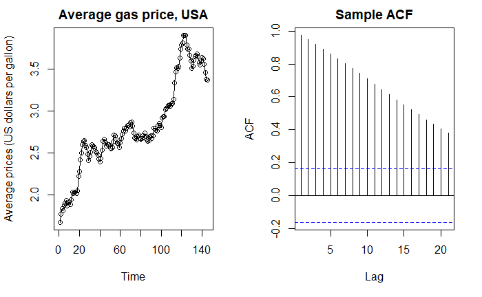

```r
# 2(a)
gasprices <- ts(read.table("gasprices.txt", quote="\"", comment.char=""))
par(mfrow=c(1,2))
plot(gasprices, ylab="Average prices (US dollars per gallon)",xlab="Time",type="o"
     , main="Average gas price, USA")
acf(gasprices,main="Sample ACF")
```

```r
# ADF test
adf.test(gasprices)
```

```
    Augmented Dickey-Fuller Test

data:  gasprices
Dickey-Fuller = -2.0655, Lag order = 5, p-value = 0.5492
alternative hypothesis: stationary
```

**Answer**:  
- Time series plot ==> Mean is not zero and a linear upward trend ==> Non-stationary  
- Sample ACF ==> Ddecays slowly ==> Non-stationary  
- adf.test(gasprices): p-value(0.5492) ==> does not reject the null hypothesis. ==> There is insufficient evidence to conclude that the process is stationary.

## 2(b)

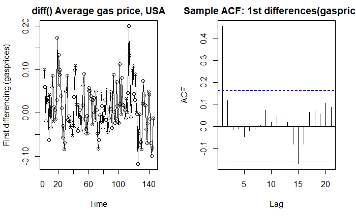

```r
# 2(b)
par(mfrow=c(1,2))
plot(diff(gasprices),ylab="First differencing (gasprices)",xlab="Time",type="o"
     , main="diff() Average gas price, USA")
acf(diff(gasprices),main="Sample ACF: 1st differences(gasprices)")
```

```r
# ADF test
adf.test(diff(gasprices))
```

```
p-value smaller than printed p-value
```

```
    Augmented Dickey-Fuller Test

data:  diff(gasprices)
Dickey-Fuller = -4.4215, Lag order = 5, p-value = 0.01
alternative hypothesis: stationary
```

**Answer**:  
- Time series plot of first differencing ==> It is better then the time series plot but it is not still mean zero, the points hang together and there are some big fluctuations. In my view it would not stationary.  
- Sample ACF: It has a big spike at lag 1 and a small one at lag 15. It is similar to an MA(1) process, but still I think it would not stationary.  
- adf.test(): p-value(0.01) is small ==> rejects the null hypothesis ==> There is sufficient evidence to formally conclude that the process is stationary.

## 2(c)

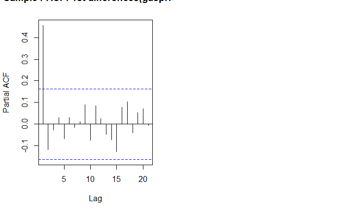

```r
# 2(c)
par(mfrow=c(1,2))
pacf(diff(gasprices),main=" Sample PACF: 1st differences(gasprices)")
```

```r
eacf(diff(gasprices))
```

```
AR/MA
  0 1 2 3 4 5 6 7 8 9 10 11 12 13
0 x o o o o o o o o o o  o  o  o
1 x o o o o o o o o o o  o  o  o
2 x x o o o o o o o o o  o  o  o
3 x o o o o o o o o o o  o  o  o
4 x x o o o o o o o o o  o  o  o
5 x o o o o o o o o o o  o  o  o
6 x o o o o o o o o o o  o  o  o
7 x o o x o x o o o o o  o  o  o
```